# Annual Report Data Analysis - Question 2.01 and 2.02

Cristin Young and Tristan Burgess

2025-12-10

This notebook answers Question 2.01: Did successful transition rates out of EBP/CDEP services differ by location?

and Question 2.02: Did successful transition rates out of EBP/CDEP services differ by subpopulations?

#Read in data

```r
install.packages("svglite")
```

# Question 2.01: Did successful transition rates out of EBP/CDEP services differ by location?

THREE inclusion criteria: 1. must have initial time point data (i.e., be enrolled in an intervention), 2. must have a valid reason for discharge selected at time of discharge (i.e., excludes those with “no reason selected”), 3. client must be attached to a specific grantee location

##Make a table of participation and completion rates by location

## % reported Mutually agreed upon cessation of Tx/successful completion at Discharge by location

| location | total | successful | perc_success |
| --- | --- | --- | --- |
| A Balanced Life, Inc. | 13 | 13 | 100.0 |
| A Greater Hope - Victorville | 2 | 0 | 0.0 |
| Achieve Residential Center | 4 | 4 | 100.0 |
| Alameda County Public Health Department | 37 | 36 | 97.3 |
| Alisal Integrated Health Center | 4 | 4 | 100.0 |
| Almond Acres Charter Academy | 2 | 0 | 0.0 |
| Alpha Behavioral Counseling Center | 4 | 4 | 100.0 |
| Amador High School | 7 | 7 | 100.0 |
| Arlington Regional Learning Center -RCOE | 1 | 1 | 100.0 |
| Arrowview Middle School | 26 | 26 | 100.0 |

[output cut: 476 more lines]

## % reported Mutually agreed upon cessation of Tx/successful completion at discharge by Region

| region | total | successful | perc_success |
| --- | --- | --- | --- |
| 1 | 820 | 793 | 96.7 |
| 10 | 408 | 400 | 98.0 |
| 11 | 1876 | 1873 | 99.8 |
| 2 | 177 | 171 | 96.6 |
| 3 | 605 | 573 | 94.7 |
| 4 | 49 | 43 | 87.8 |
| 5 | 296 | 287 | 97.0 |
| 6 | 266 | 239 | 89.8 |
| 7 | 656 | 572 | 87.2 |
| 8 | 1073 | 1044 | 97.3 |

[output cut: 2 more lines]

###Mapping by region

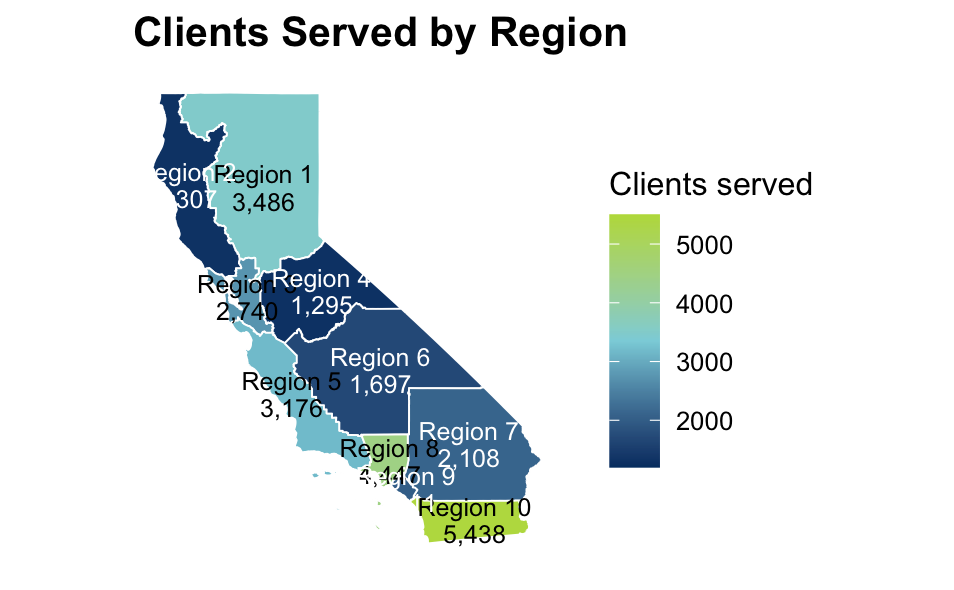

###Mapping by primary county

```r
library(sf)
library(tigris)
options(tigris_use_cache = TRUE)

ca_counties <- counties("CA", cb = TRUE, class = "sf") %>%
  janitor::clean_names()

#plot counties
ggplot(ca_counties) +
  geom_sf(aes(fill = factor(name)), color = "white", linewidth = 0.3) +
  scale_fill_viridis_d(name = "Region") +
  theme_minimal() +
  labs(title = "California Census Regions (1–10)")

#get % success at county level
county_success <- data201_spss %>%
  rename(primary_county = `8a_primary_county`) %>%
  group_by(primary_county) %>%
  summarise(
    total = n(),
    successful = sum(reason_for_discharge %in% c("Mutually agreed cessation of treatment (Successful Completion)","Clinically referred out"), na.rm = TRUE),
    perc_success = round(100 * successful / total, 1)
  )

#now merge with outcomes data
county_map_data <- ca_counties %>%
  left_join(county_success, by = c(name = "primary_county"))

#make labels
x_push <- diff(st_bbox(county_map_data)[c("xmin","xmax")]) * 0.45  # big push to the right

#plot
ggplot(county_map_data) +
  geom_sf(aes(fill = perc_success), color = "white", linewidth = 0.3) +
  geom_text_repel(
    data = county_map_data %>% filter(perc_success < threshold),
    aes(geometry = geometry,
        label = paste0(name, "\n", perc_success, "%")
        ),
    color = "black",
    stat = "sf_coordinates",
    nudge_x = -x_push,
    direction = "y",
    hjust = 1,
    box.padding = 0.6,
    point.padding = 0.4,
    #force = 8,
    max.overlaps = Inf,
    min.segment.length = 0,
    segment.size = 0.4,
    size = 3.2
  ) +
  scale_fill_viridis_c(
    option = "C",
    direction = -1,
    name = "% successful",
    limits = c(50, 100)
  ) +
  labs(
    title = "% Successful Outcomes by Primary County",
    subtitle = "Primary counties with <75% successful completion labeled",
    fill = "% success"
  )+
  theme_minimal() +
  theme(
    axis.text = element_blank(),
    axis.title = element_blank(),
    panel.grid = element_blank(),
    plot.title = element_text(size = 14, face = "bold"),
    plot.subtitle = element_text(size = 11)
  ) +
  coord_sf(clip = "off")
```

[output not shown]

## % of those who met Tx goals (% successful completion + improved score) by location”

```r
table(data201$reason_for_discharge)

data201_txgoals <- data201 %>%
  filter(reason_for_discharge == "Mutually agreed cessation of treatment (Successful Completion)" | reason_for_discharge == "Clinically referred out",
         positive_outcomes == "Yes")

data201 %>%
  filter(positive_outcomes == "Yes") %>%
  tabyl(reason_for_discharge) %>%
  adorn_pct_formatting(digits = 1) %>%
  adorn_totals("row")

# perc_successful_table_pos_outcome <- data201 %>%
#   group_by(location) %>%
#   summarise(
#     total = n(),
#     successful_discharge = sum(reason_for_discharge %in% c("Mutually agreed cessation of treatment (Successful Completion)","Clinically referred out"), na.rm = TRUE),
#     perc_success_discharge = round(100 * successful_discharge / total, 1),
#     successful_outcome = sum(positive_outcomes %in% c("Yes"), na.rm = TRUE),
#     perc_success_outcome = round(100 * successful_outcome / total, 1)
#   )
#
# perc_successful_table_pos_outcome %>%
#   knitr::kable() %>%
#   clipr::write_clip(allow_non_interactive = TRUE)

xlsx::write.xlsx(perc_successful_table,"/Users/cristin/CWS Dropbox/Cristin Young/CYBHI Project/Rebecca and Tristan and Cristin/Annual Report Development/Results Tables/Q2.01/perc_successful_table_pos_outcome.xlsx")

#or
p_yes = function(x) round(x[2]/sum(x), 2) # 1 in this line was doing p_no!

table <- addmargins(xtabs(data=data201, ~location + positive_outcomes, subset = data201$reason_for_discharge == "Mutually agreed cessation of treatment (Successful Completion)"), FUN = list(p_yes))

table %>%
  knitr::kable() %>%
  clipr::write_clip(allow_non_interactive = TRUE)

xlsx::write.xlsx(perc_successful_table,"/Users/cristin/CWS Dropbox/Cristin Young/CYBHI Project/Rebecca and Tristan and Cristin/Annual Report Development/Results Tables/Q2.01/Mutually agreed cessation of treatment (Successful Completion).xlsx")
```

#Question 2.02: Did successful transition rates out of EBP/CDEP services differ by subpopulations? look at data201 by demographics

##Race

```r
detailed_race <- data201 %>%
  group_by(code_num) %>%
  summarise(
    total = n(),
    successful = sum(reason_for_discharge %in% c("Mutually agreed cessation of treatment (Successful Completion)","Clinically referred out"), na.rm = TRUE),
    perc_success = round(100* successful / total, 1)
  )

detailed_race %>%
  knitr::kable() %>%
  clipr::write_clip(allow_non_interactive = TRUE)

chisq.test(data201$positive_outcomes, data201$code_num)

# data201$code_num %>%
#   mutate(race_factor = fct_recode(code_num,
#                                   "Asian" = 1,
#               "Black or African American" = 2,
#                      "Hispanic or Latino" = 3,
#         "Middle Eastern or North African" = 4,
#               "Native American/American Indian or Alaska Native" = 5,
#               "Native Hawaiian or Pacific Islander" = 6,
#               "White" = 7,
#               "2+ selected" = 88
#               ))

# model <- glm(positive_outcomes ~ factor(code_num), data = data201, family = "binomial")
# summary(model)

openxlsx::write.xlsx(summary(model)$coefficients,"/Users/cristin/CWS Dropbox/Cristin Young/CYBHI Project/Rebecca and Tristan and Cristin/Annual Report Development/Results Tables/Q2.02/detailed race (model).xlsx")
```

##Race summary Roll detailed race variables, based on first answer, up into: - Asian - Black or African American - Don’t Know - Hispanic or Latino - Middle Eastern or North African - Native American/American Indian or Alaska Native - Native Hawaiian or Pacific Islander - Not Applicable - Prefer Not to Answer - White

```r
#make new column of only the first race recorded
data201 <- data201 %>%
  separate(race, into = c("first_race", NA), sep = ",", extra = "drop", remove = FALSE)

summary_race <- data201 %>%
  group_by(first_race) %>%
  summarise(
    total = n(),
    successful = sum(reason_for_discharge %in% c("Mutually agreed cessation of treatment (Successful Completion)","Clinically referred out"), na.rm = TRUE),
    perc_success = round(100* successful / total, 1)
  )

summary_race %>%
  knitr::kable() %>%
  clipr::write_clip(allow_non_interactive = TRUE)

openxlsx::write.xlsx(summary_race,"/Users/cristin/CWS Dropbox/Cristin Young/CYBHI Project/Rebecca and Tristan and Cristin/Annual Report Development/Results Tables/Q2.02/summary_race.xlsx")

chisq.test(data201$positive_outcomes, data201$first_race)

model <- glm(positive_outcomes ~ first_race, data = data201, family = "binomial")
summary(model)
table(data201$first_race)

xlsx::write.xlsx(summary(model)$coefficients,"/Users/cristin/CWS Dropbox/Cristin Young/CYBHI Project/Rebecca and Tristan and Cristin/Annual Report Development/Results Tables/Q2.02/summary race (model).xlsx")
```

##Ethnicity codebook_eth <- c(“Chinese” = 1, “Asian Indian” = 2, “Filipino” = 3, “Vietnamese” = 4, “Korean” = 5,“Japanese” = 6, “African American” = 7,“Jamaican” = 8, “Haitian” = 9, “Nigerian” = 10, “Somali” = 11, “Mexican” = 12, “Puerto Rican” = 13, “Salvadoran” = 14, “Cuban” = 15, “Dominican” = 16, “Guatemalan” = 17, “Native Hawaiian” = 18, “Samoan” = 19, “Chamorro” = 20, “English” = 21, “German” = 22, “Irish” = 23, “Italian” = 24, “Polish” = 25, “Scottish” = 26, “2+ ethnicities selected” = 88)

```r
detailed_ethnicity <- data201 %>%
  group_by(ethn_num) %>%
  summarise(
    total = n(),
    successful = sum(reason_for_discharge %in% c("Mutually agreed cessation of treatment (Successful Completion)","Clinically referred out"), na.rm = TRUE),
    perc_success = round(100* successful / total, 1)
  )

detailed_ethnicity %>%
  knitr::kable() %>%
  clipr::write_clip(allow_non_interactive = TRUE)

xlsx::write.xlsx(detailed_ethnicity,"/Users/cristin/CWS Dropbox/Cristin Young/CYBHI Project/Rebecca and Tristan and Cristin/Annual Report Development/Results Tables/Q2.02/detailed_ethnicity.xlsx")

chisq.test(data201$positive_outcomes, data201$ethnicity)
```

##Gender Identity

```r
gender_identity <- data201 %>%
  group_by(gender_identity) %>%
  summarise(
    total = n(),
    successful = sum(reason_for_discharge %in% c("Mutually agreed cessation of treatment (Successful Completion)","Clinically referred out"), na.rm = TRUE),
    perc_success = round(100* successful / total, 1)
  )

gender_identity %>%
  knitr::kable() %>%
  clipr::write_clip(allow_non_interactive = TRUE)

openxlsx::write.xlsx(gender_identity,"/Users/cristin/CWS Dropbox/Cristin Young/CYBHI Project/Rebecca and Tristan and Cristin/Annual Report Development/Results Tables/Q2.02/gender_identity.xlsx")

chisq.test(data201$gender_identity, data201$positive_outcomes)

data201$gender_identity <- relevel(as.factor(data201$gender_identity),ref="Woman/girl")

model <- glm(positive_outcomes ~ gender_identity, data = data201, family = "binomial")

summary(model)

openxlsx::write.xlsx(summary(model)$coefficients,"/Users/cristin/CWS Dropbox/Cristin Young/CYBHI Project/Rebecca and Tristan and Cristin/Annual Report Development/Results Tables/Q2.02/gender_identity(model).xlsx")
```

##Sexual orientation

```r
sex_orientation <- data201 %>%
  group_by(sexual_orientation) %>%
  summarise(
    total = n(),
    successful = sum(reason_for_discharge %in% c("Mutually agreed cessation of treatment (Successful Completion)","Clinically referred out"), na.rm = TRUE),
    perc_success = round(100* successful / total, 1)
  )

sex_orientation %>%
  knitr::kable() %>%
  clipr::write_clip(allow_non_interactive = TRUE)

openxlsx::write.xlsx(sex_orientation,"/Users/cristin/CWS Dropbox/Cristin Young/CYBHI Project/Rebecca and Tristan and Cristin/Annual Report Development/Results Tables/Q2.02/sex_orientation.xlsx")

chisq.test(data201$positive_outcomes, data201$sexual_orientation)

model <- glm(positive_outcomes ~ sexual_orientation, data = data201, family = "binomial")

summary(model)
```

##Insurance status

```r
insurance <- data201 %>%
  group_by(insurance_status) %>%
  summarise(
    total = n(),
    successful = sum(reason_for_discharge %in% c("Mutually agreed cessation of treatment (Successful Completion)","Clinically referred out"), na.rm = TRUE),
    perc_success = round(100* successful / total, 1)
  )

insurance %>%
  knitr::kable() %>%
  clipr::write_clip(allow_non_interactive = TRUE)

openxlsx::write.xlsx(insurance,"/Users/cristin/CWS Dropbox/Cristin Young/CYBHI Project/Rebecca and Tristan and Cristin/Annual Report Development/Results Tables/Q2.02/insurance.xlsx")

chisq.test(data201$positive_outcomes, data201$insurance_status)

model <- glm(positive_outcomes ~ insurance_status, data = data201, family = "binomial")
summary(model)

openxlsx::write.xlsx(summary(model)$coefficients,"/Users/cristin/CWS Dropbox/Cristin Young/CYBHI Project/Rebecca and Tristan and Cristin/Annual Report Development/Results Tables/Q2.02/insurance(model).xlsx")
```